# Risk Factor Analysis

## Outcome Variable

**Outcome Variable:** stunted

## Predictor Variables

**Intervention Variable:** hdlvry

**Adjustment Set:**

- arm
- sex
- W_mage
- meducyrs
- feducyrs
- hhwealth_quart
- single
- W_nrooms
- brthmon
- W_parity
- impsan
- delta_W_mage
- delta_meducyrs
- delta_feducyrs
- delta_hhwealth_quart
- delta_single
- delta_W_nrooms
- delta_brthmon
- delta_W_parity
- delta_impsan

## Stratifying Variables

The analysis was stratified on these variable(s):

- agecat
- studyid
- country

## Data Summary

| agecat | studyid | country | hdlvry | stunted | n_cell | n |
| --- | --- | --- | --- | --- | --- | --- |
| Birth | ki1000108-CMC-V-BCS-2002 | INDIA | 0 | 0 | 75 | 92 |
| Birth | ki1000108-CMC-V-BCS-2002 | INDIA | 0 | 1 | 17 | 92 |
| Birth | ki1000108-CMC-V-BCS-2002 | INDIA | 1 | 0 | 0 | 92 |
| Birth | ki1000108-CMC-V-BCS-2002 | INDIA | 1 | 1 | 0 | 92 |
| Birth | ki1000108-IRC | INDIA | 0 | 0 | 337 | 388 |
| Birth | ki1000108-IRC | INDIA | 0 | 1 | 44 | 388 |
| Birth | ki1000108-IRC | INDIA | 1 | 0 | 6 | 388 |
| Birth | ki1000108-IRC | INDIA | 1 | 1 | 1 | 388 |
| Birth | ki1000109-EE | PAKISTAN | 0 | 0 | 93 | 238 |
| Birth | ki1000109-EE | PAKISTAN | 0 | 1 | 68 | 238 |
| Birth | ki1000109-EE | PAKISTAN | 1 | 0 | 46 | 238 |
| Birth | ki1000109-EE | PAKISTAN | 1 | 1 | 31 | 238 |
| Birth | ki1000304b-SAS-CompFeed | INDIA | 0 | 0 | 85 | 1085 |
| Birth | ki1000304b-SAS-CompFeed | INDIA | 0 | 1 | 39 | 1085 |
| Birth | ki1000304b-SAS-CompFeed | INDIA | 1 | 0 | 692 | 1085 |
| Birth | ki1000304b-SAS-CompFeed | INDIA | 1 | 1 | 269 | 1085 |
| Birth | ki1017093b-PROVIDE | BANGLADESH | 0 | 0 | 355 | 539 |
| Birth | ki1017093b-PROVIDE | BANGLADESH | 0 | 1 | 36 | 539 |
| Birth | ki1017093b-PROVIDE | BANGLADESH | 1 | 0 | 136 | 539 |
| Birth | ki1017093b-PROVIDE | BANGLADESH | 1 | 1 | 12 | 539 |
| Birth | ki1017093c-NIH-Crypto | BANGLADESH | 0 | 0 | 495 | 732 |
| Birth | ki1017093c-NIH-Crypto | BANGLADESH | 0 | 1 | 72 | 732 |
| Birth | ki1017093c-NIH-Crypto | BANGLADESH | 1 | 0 | 136 | 732 |
| Birth | ki1017093c-NIH-Crypto | BANGLADESH | 1 | 1 | 29 | 732 |
| Birth | ki1113344-GMS-Nepal | NEPAL | 0 | 0 | 125 | 646 |
| Birth | ki1113344-GMS-Nepal | NEPAL | 0 | 1 | 32 | 646 |
| Birth | ki1113344-GMS-Nepal | NEPAL | 1 | 0 | 408 | 646 |
| Birth | ki1113344-GMS-Nepal | NEPAL | 1 | 1 | 81 | 646 |
| Birth | ki1135781-COHORTS | INDIA | 0 | 0 | 2613 | 4694 |
| Birth | ki1135781-COHORTS | INDIA | 0 | 1 | 325 | 4694 |

[output cut: 98 more lines]

The following strata were considered:

- agecat: 24 months, studyid: ki1000108-CMC-V-BCS-2002, country: INDIA
- agecat: 24 months, studyid: ki1000108-IRC, country: INDIA
- agecat: 24 months, studyid: ki1000109-EE, country: PAKISTAN
- agecat: 24 months, studyid: ki1017093b-PROVIDE, country: BANGLADESH
- agecat: 24 months, studyid: ki1017093c-NIH-Crypto, country: BANGLADESH
- agecat: 24 months, studyid: ki1066203-TanzaniaChild2, country: TANZANIA, UNITED REPUBLIC OF
- agecat: 24 months, studyid: ki1113344-GMS-Nepal, country: NEPAL
- agecat: 24 months, studyid: ki1135781-COHORTS, country: INDIA
- agecat: 24 months, studyid: kiGH5241-JiVitA-3, country: BANGLADESH
- agecat: 24 months, studyid: kiGH5241-JiVitA-4, country: BANGLADESH
- agecat: 6 months, studyid: ki1000108-CMC-V-BCS-2002, country: INDIA
- agecat: 6 months, studyid: ki1000108-IRC, country: INDIA
- agecat: 6 months, studyid: ki1000109-EE, country: PAKISTAN
- agecat: 6 months, studyid: ki1000304b-SAS-CompFeed, country: INDIA
- agecat: 6 months, studyid: ki1000304b-SAS-FoodSuppl, country: INDIA
- agecat: 6 months, studyid: ki1017093b-PROVIDE, country: BANGLADESH
- agecat: 6 months, studyid: ki1017093c-NIH-Crypto, country: BANGLADESH
- agecat: 6 months, studyid: ki1066203-TanzaniaChild2, country: TANZANIA, UNITED REPUBLIC OF
- agecat: 6 months, studyid: ki1113344-GMS-Nepal, country: NEPAL
- agecat: 6 months, studyid: ki1135781-COHORTS, country: INDIA
- agecat: 6 months, studyid: kiGH5241-JiVitA-3, country: BANGLADESH
- agecat: 6 months, studyid: kiGH5241-JiVitA-4, country: BANGLADESH
- agecat: Birth, studyid: ki1000108-CMC-V-BCS-2002, country: INDIA
- agecat: Birth, studyid: ki1000108-IRC, country: INDIA
- agecat: Birth, studyid: ki1000109-EE, country: PAKISTAN
- agecat: Birth, studyid: ki1000304b-SAS-CompFeed, country: INDIA
- agecat: Birth, studyid: ki1017093b-PROVIDE, country: BANGLADESH
- agecat: Birth, studyid: ki1017093c-NIH-Crypto, country: BANGLADESH
- agecat: Birth, studyid: ki1113344-GMS-Nepal, country: NEPAL
- agecat: Birth, studyid: ki1135781-COHORTS, country: INDIA
- agecat: Birth, studyid: kiGH5241-JiVitA-3, country: BANGLADESH
- agecat: Birth, studyid: kiGH5241-JiVitA-4, country: BANGLADESH

### Dropped Strata

Some strata were dropped due to rare outcomes:

- agecat: Birth, studyid: ki1000108-CMC-V-BCS-2002, country: INDIA
- agecat: Birth, studyid: ki1000108-IRC, country: INDIA
- agecat: 6 months, studyid: ki1000108-CMC-V-BCS-2002, country: INDIA
- agecat: 6 months, studyid: ki1000108-IRC, country: INDIA
- agecat: 24 months, studyid: ki1000108-CMC-V-BCS-2002, country: INDIA
- agecat: 24 months, studyid: ki1000108-IRC, country: INDIA
- agecat: 24 months, studyid: ki1066203-TanzaniaChild2, country: TANZANIA, UNITED REPUBLIC OF

## Methods Detail

We’re interested in the causal parameters $E[Y_a]$ for all values of $a \in \mathcal{A}$. These parameters represent the mean outcome if, possibly contrary to fact, we intervened to set all units to have $A=a$. Under the randomization and positivity assumptions, these are identified by the statistical parameters $\psi_a=E_W[E_{Y|A,W}(Y|A=a,W)]$. In addition, we’re interested in the mean of $Y$, $E[Y]$ under no intervention (the observed mean). We will estimate these parameters by using SuperLearner to fit the relevant likelihood factors – $E_{Y|A,W}(Y|A=a,W)$ and $p(A=a|W)$, and then updating our likelihood fit using a joint TMLE.

For unadjusted analyses ($W=\{\}$), initial likelihoods were estimated using Lrnr_glm to estimate the simple $E(Y|A)$ and Lrnr_mean to estimate $p(A)$. For adjusted analyses, a small library containing Lrnr_glmnet, Lrnr_xgboost, and Lrnr_mean was used.

Having estimated these parameters, we will then use the delta method to estimate relative risks and attributable risks relative to a prespecified baseline level of $A$.

# Results Detail

## Results Plots

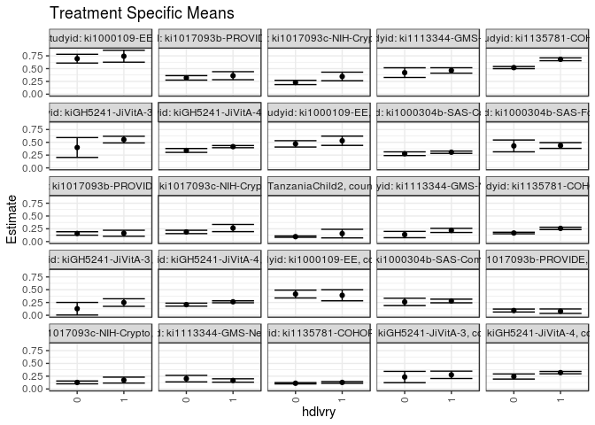

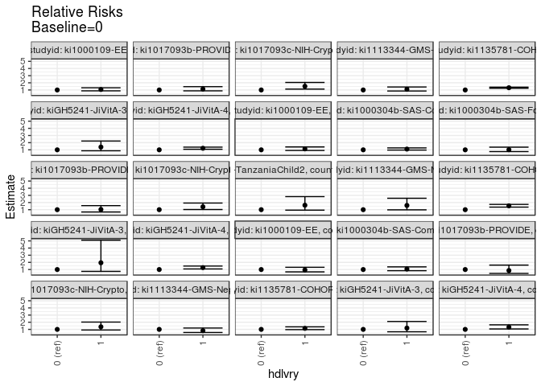

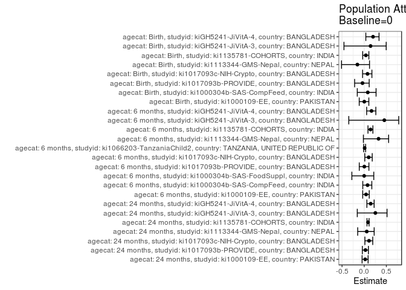

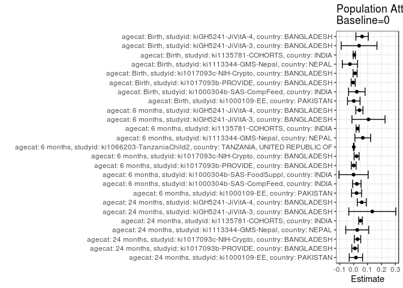

## Results Table

### Parameter: TSM

| agecat | studyid | country | intervention_level | baseline_level | estimate | ci_lower | ci_upper |
| --- | --- | --- | --- | --- | --- | --- | --- |
| Birth | ki1000109-EE | PAKISTAN | 0 | NA | 0.4150382 | 0.3384247 | 0.4916516 |
| Birth | ki1000109-EE | PAKISTAN | 1 | NA | 0.3904230 | 0.2828782 | 0.4979678 |
| Birth | ki1000304b-SAS-CompFeed | INDIA | 0 | NA | 0.2610806 | 0.1892690 | 0.3328922 |
| Birth | ki1000304b-SAS-CompFeed | INDIA | 1 | NA | 0.2793671 | 0.2435570 | 0.3151771 |
| Birth | ki1017093b-PROVIDE | BANGLADESH | 0 | NA | 0.0925175 | 0.0636372 | 0.1213978 |
| Birth | ki1017093b-PROVIDE | BANGLADESH | 1 | NA | 0.0797705 | 0.0362725 | 0.1232684 |
| Birth | ki1017093c-NIH-Crypto | BANGLADESH | 0 | NA | 0.1277057 | 0.1001995 | 0.1552119 |
| Birth | ki1017093c-NIH-Crypto | BANGLADESH | 1 | NA | 0.1735270 | 0.1157133 | 0.2313406 |
| Birth | ki1113344-GMS-Nepal | NEPAL | 0 | NA | 0.2017528 | 0.1378907 | 0.2656148 |
| Birth | ki1113344-GMS-Nepal | NEPAL | 1 | NA | 0.1657710 | 0.1327751 | 0.1987669 |
| Birth | ki1135781-COHORTS | INDIA | 0 | NA | 0.1120872 | 0.1000036 | 0.1241708 |
| Birth | ki1135781-COHORTS | INDIA | 1 | NA | 0.1282228 | 0.1113477 | 0.1450979 |
| Birth | kiGH5241-JiVitA-3 | BANGLADESH | 0 | NA | 0.2333333 | 0.1228972 | 0.3437694 |
| Birth | kiGH5241-JiVitA-3 | BANGLADESH | 1 | NA | 0.2763158 | 0.2043428 | 0.3482888 |
| Birth | kiGH5241-JiVitA-4 | BANGLADESH | 0 | NA | 0.2431493 | 0.1933997 | 0.2928989 |
| Birth | kiGH5241-JiVitA-4 | BANGLADESH | 1 | NA | 0.3199733 | 0.2970923 | 0.3428544 |
| 6 months | ki1000109-EE | PAKISTAN | 0 | NA | 0.4696044 | 0.4075443 | 0.5316646 |
| 6 months | ki1000109-EE | PAKISTAN | 1 | NA | 0.5304817 | 0.4398240 | 0.6211395 |
| 6 months | ki1000304b-SAS-CompFeed | INDIA | 0 | NA | 0.2771157 | 0.2407162 | 0.3135151 |
| 6 months | ki1000304b-SAS-CompFeed | INDIA | 1 | NA | 0.3059842 | 0.2836611 | 0.3283072 |
| 6 months | ki1000304b-SAS-FoodSuppl | INDIA | 0 | NA | 0.4294652 | 0.3139770 | 0.5449535 |
| 6 months | ki1000304b-SAS-FoodSuppl | INDIA | 1 | NA | 0.4370452 | 0.3810031 | 0.4930873 |
| 6 months | ki1017093b-PROVIDE | BANGLADESH | 0 | NA | 0.1584111 | 0.1246566 | 0.1921656 |
| 6 months | ki1017093b-PROVIDE | BANGLADESH | 1 | NA | 0.1630821 | 0.1041973 | 0.2219669 |
| 6 months | ki1017093c-NIH-Crypto | BANGLADESH | 0 | NA | 0.1885574 | 0.1559206 | 0.2211942 |
| 6 months | ki1017093c-NIH-Crypto | BANGLADESH | 1 | NA | 0.2646923 | 0.1944805 | 0.3349041 |
| 6 months | ki1066203-TanzaniaChild2 | TANZANIA, UNITED REPUBLIC OF | 0 | NA | 0.0963473 | 0.0829238 | 0.1097708 |
| 6 months | ki1066203-TanzaniaChild2 | TANZANIA, UNITED REPUBLIC OF | 1 | NA | 0.1562500 | 0.0724034 | 0.2400966 |
| 6 months | ki1113344-GMS-Nepal | NEPAL | 0 | NA | 0.1370008 | 0.0755395 | 0.1984621 |
| 6 months | ki1113344-GMS-Nepal | NEPAL | 1 | NA | 0.2182348 | 0.1776336 | 0.2588360 |
| 6 months | ki1135781-COHORTS | INDIA | 0 | NA | 0.1676735 | 0.1528377 | 0.1825093 |
| 6 months | ki1135781-COHORTS | INDIA | 1 | NA | 0.2575131 | 0.2351732 | 0.2798529 |
| 6 months | kiGH5241-JiVitA-3 | BANGLADESH | 0 | NA | 0.1282051 | 0.0052540 | 0.2511562 |
| 6 months | kiGH5241-JiVitA-3 | BANGLADESH | 1 | NA | 0.2491468 | 0.1752336 | 0.3230600 |
| 6 months | kiGH5241-JiVitA-4 | BANGLADESH | 0 | NA | 0.2077232 | 0.1781972 | 0.2372491 |
| 6 months | kiGH5241-JiVitA-4 | BANGLADESH | 1 | NA | 0.2635075 | 0.2439694 | 0.2830456 |
| 24 months | ki1000109-EE | PAKISTAN | 0 | NA | 0.6945457 | 0.6084920 | 0.7805993 |
| 24 months | ki1000109-EE | PAKISTAN | 1 | NA | 0.7424926 | 0.6260305 | 0.8589547 |
| 24 months | ki1017093b-PROVIDE | BANGLADESH | 0 | NA | 0.3193286 | 0.2753845 | 0.3632726 |
| 24 months | ki1017093b-PROVIDE | BANGLADESH | 1 | NA | 0.3612625 | 0.2827872 | 0.4397378 |
| 24 months | ki1017093c-NIH-Crypto | BANGLADESH | 0 | NA | 0.2288886 | 0.1870756 | 0.2707016 |
| 24 months | ki1017093c-NIH-Crypto | BANGLADESH | 1 | NA | 0.3468218 | 0.2626779 | 0.4309658 |
| 24 months | ki1113344-GMS-Nepal | NEPAL | 0 | NA | 0.4217261 | 0.3269008 | 0.5165515 |
| 24 months | ki1113344-GMS-Nepal | NEPAL | 1 | NA | 0.4644213 | 0.4113628 | 0.5174799 |
| 24 months | ki1135781-COHORTS | INDIA | 0 | NA | 0.5198648 | 0.4986347 | 0.5410949 |
| 24 months | ki1135781-COHORTS | INDIA | 1 | NA | 0.6820464 | 0.6543146 | 0.7097782 |
| 24 months | kiGH5241-JiVitA-3 | BANGLADESH | 0 | NA | 0.3987211 | 0.2046473 | 0.5927948 |
| 24 months | kiGH5241-JiVitA-3 | BANGLADESH | 1 | NA | 0.5531089 | 0.4878179 | 0.6183998 |
| 24 months | kiGH5241-JiVitA-4 | BANGLADESH | 0 | NA | 0.3408728 | 0.3029461 | 0.3787994 |
| 24 months | kiGH5241-JiVitA-4 | BANGLADESH | 1 | NA | 0.4153527 | 0.3939187 | 0.4367866 |

### Parameter: E(Y)

| agecat | studyid | country | intervention_level | baseline_level | estimate | ci_lower | ci_upper |
| --- | --- | --- | --- | --- | --- | --- | --- |
| Birth | ki1000109-EE | PAKISTAN | NA | NA | 0.4159664 | 0.3532152 | 0.4787176 |
| Birth | ki1000304b-SAS-CompFeed | INDIA | NA | NA | 0.2838710 | 0.2475589 | 0.3201830 |
| Birth | ki1017093b-PROVIDE | BANGLADESH | NA | NA | 0.0890538 | 0.0649864 | 0.1131212 |
| Birth | ki1017093c-NIH-Crypto | BANGLADESH | NA | NA | 0.1379781 | 0.1129774 | 0.1629789 |
| Birth | ki1113344-GMS-Nepal | NEPAL | NA | NA | 0.1749226 | 0.1456043 | 0.2042409 |
| Birth | ki1135781-COHORTS | INDIA | NA | NA | 0.1165317 | 0.1073518 | 0.1257117 |
| Birth | kiGH5241-JiVitA-3 | BANGLADESH | NA | NA | 0.2724551 | 0.2076543 | 0.3372559 |
| Birth | kiGH5241-JiVitA-4 | BANGLADESH | NA | NA | 0.3037749 | 0.2834613 | 0.3240886 |
| 6 months | ki1000109-EE | PAKISTAN | NA | NA | 0.4905660 | 0.4396283 | 0.5415038 |
| 6 months | ki1000304b-SAS-CompFeed | INDIA | NA | NA | 0.2997250 | 0.2767096 | 0.3227405 |
| 6 months | ki1000304b-SAS-FoodSuppl | INDIA | NA | NA | 0.4289474 | 0.3791199 | 0.4787748 |
| 6 months | ki1017093b-PROVIDE | BANGLADESH | NA | NA | 0.1589404 | 0.1297581 | 0.1881227 |
| 6 months | ki1017093c-NIH-Crypto | BANGLADESH | NA | NA | 0.2097902 | 0.1799252 | 0.2396552 |
| 6 months | ki1066203-TanzaniaChild2 | TANZANIA, UNITED REPUBLIC OF | NA | NA | 0.0973451 | 0.0840860 | 0.1106043 |
| 6 months | ki1113344-GMS-Nepal | NEPAL | NA | NA | 0.2026515 | 0.1683319 | 0.2369711 |
| 6 months | ki1135781-COHORTS | INDIA | NA | NA | 0.1955735 | 0.1842315 | 0.2069155 |
| 6 months | kiGH5241-JiVitA-3 | BANGLADESH | NA | NA | 0.2349398 | 0.1664503 | 0.3034292 |
| 6 months | kiGH5241-JiVitA-4 | BANGLADESH | NA | NA | 0.2488856 | 0.2328153 | 0.2649558 |
| 24 months | ki1000109-EE | PAKISTAN | NA | NA | 0.7108434 | 0.6416667 | 0.7800200 |
| 24 months | ki1017093b-PROVIDE | BANGLADESH | NA | NA | 0.3287197 | 0.2903909 | 0.3670485 |
| 24 months | ki1017093c-NIH-Crypto | BANGLADESH | NA | NA | 0.2568093 | 0.2190047 | 0.2946140 |
| 24 months | ki1113344-GMS-Nepal | NEPAL | NA | NA | 0.4473684 | 0.4016814 | 0.4930554 |
| 24 months | ki1135781-COHORTS | INDIA | NA | NA | 0.5691789 | 0.5529008 | 0.5854569 |
| 24 months | kiGH5241-JiVitA-3 | BANGLADESH | NA | NA | 0.5326460 | 0.4663548 | 0.5989373 |
| 24 months | kiGH5241-JiVitA-4 | BANGLADESH | NA | NA | 0.3992509 | 0.3804088 | 0.4180930 |

### Parameter: RR

| agecat | studyid | country | intervention_level | baseline_level | estimate | ci_lower | ci_upper |
| --- | --- | --- | --- | --- | --- | --- | --- |
| Birth | ki1000109-EE | PAKISTAN | 0 | 0 | 1.0000000 | 1.0000000 | 1.000000 |
| Birth | ki1000109-EE | PAKISTAN | 1 | 0 | 0.9406918 | 0.6737476 | 1.313401 |
| Birth | ki1000304b-SAS-CompFeed | INDIA | 0 | 0 | 1.0000000 | 1.0000000 | 1.000000 |
| Birth | ki1000304b-SAS-CompFeed | INDIA | 1 | 0 | 1.0700414 | 0.8348403 | 1.371506 |
| Birth | ki1017093b-PROVIDE | BANGLADESH | 0 | 0 | 1.0000000 | 1.0000000 | 1.000000 |
| Birth | ki1017093b-PROVIDE | BANGLADESH | 1 | 0 | 0.8622202 | 0.4597751 | 1.616929 |
| Birth | ki1017093c-NIH-Crypto | BANGLADESH | 0 | 0 | 1.0000000 | 1.0000000 | 1.000000 |
| Birth | ki1017093c-NIH-Crypto | BANGLADESH | 1 | 0 | 1.3588039 | 0.9139340 | 2.020220 |
| Birth | ki1113344-GMS-Nepal | NEPAL | 0 | 0 | 1.0000000 | 1.0000000 | 1.000000 |
| Birth | ki1113344-GMS-Nepal | NEPAL | 1 | 0 | 0.8216543 | 0.5667295 | 1.191249 |
| Birth | ki1135781-COHORTS | INDIA | 0 | 0 | 1.0000000 | 1.0000000 | 1.000000 |
| Birth | ki1135781-COHORTS | INDIA | 1 | 0 | 1.1439555 | 0.9651987 | 1.355818 |
| Birth | kiGH5241-JiVitA-3 | BANGLADESH | 0 | 0 | 1.0000000 | 1.0000000 | 1.000000 |
| Birth | kiGH5241-JiVitA-3 | BANGLADESH | 1 | 0 | 1.1842105 | 0.6662901 | 2.104721 |
| Birth | kiGH5241-JiVitA-4 | BANGLADESH | 0 | 0 | 1.0000000 | 1.0000000 | 1.000000 |
| Birth | kiGH5241-JiVitA-4 | BANGLADESH | 1 | 0 | 1.3159540 | 1.0585992 | 1.635874 |
| 6 months | ki1000109-EE | PAKISTAN | 0 | 0 | 1.0000000 | 1.0000000 | 1.000000 |
| 6 months | ki1000109-EE | PAKISTAN | 1 | 0 | 1.1296352 | 0.9100145 | 1.402259 |
| 6 months | ki1000304b-SAS-CompFeed | INDIA | 0 | 0 | 1.0000000 | 1.0000000 | 1.000000 |
| 6 months | ki1000304b-SAS-CompFeed | INDIA | 1 | 0 | 1.1041749 | 0.9636102 | 1.265244 |
| 6 months | ki1000304b-SAS-FoodSuppl | INDIA | 0 | 0 | 1.0000000 | 1.0000000 | 1.000000 |
| 6 months | ki1000304b-SAS-FoodSuppl | INDIA | 1 | 0 | 1.0176498 | 0.7547020 | 1.372212 |
| 6 months | ki1017093b-PROVIDE | BANGLADESH | 0 | 0 | 1.0000000 | 1.0000000 | 1.000000 |
| 6 months | ki1017093b-PROVIDE | BANGLADESH | 1 | 0 | 1.0294868 | 0.6767484 | 1.566081 |
| 6 months | ki1017093c-NIH-Crypto | BANGLADESH | 0 | 0 | 1.0000000 | 1.0000000 | 1.000000 |
| 6 months | ki1017093c-NIH-Crypto | BANGLADESH | 1 | 0 | 1.4037756 | 1.0223766 | 1.927456 |
| 6 months | ki1066203-TanzaniaChild2 | TANZANIA, UNITED REPUBLIC OF | 0 | 0 | 1.0000000 | 1.0000000 | 1.000000 |
| 6 months | ki1066203-TanzaniaChild2 | TANZANIA, UNITED REPUBLIC OF | 1 | 0 | 1.6217376 | 0.9315439 | 2.823306 |
| 6 months | ki1113344-GMS-Nepal | NEPAL | 0 | 0 | 1.0000000 | 1.0000000 | 1.000000 |
| 6 months | ki1113344-GMS-Nepal | NEPAL | 1 | 0 | 1.5929455 | 0.9778472 | 2.594961 |
| 6 months | ki1135781-COHORTS | INDIA | 0 | 0 | 1.0000000 | 1.0000000 | 1.000000 |
| 6 months | ki1135781-COHORTS | INDIA | 1 | 0 | 1.5358001 | 1.3572105 | 1.737890 |
| 6 months | kiGH5241-JiVitA-3 | BANGLADESH | 0 | 0 | 1.0000000 | 1.0000000 | 1.000000 |
| 6 months | kiGH5241-JiVitA-3 | BANGLADESH | 1 | 0 | 1.9433447 | 0.7402346 | 5.101881 |
| 6 months | kiGH5241-JiVitA-4 | BANGLADESH | 0 | 0 | 1.0000000 | 1.0000000 | 1.000000 |
| 6 months | kiGH5241-JiVitA-4 | BANGLADESH | 1 | 0 | 1.2685512 | 1.0820085 | 1.487255 |
| 24 months | ki1000109-EE | PAKISTAN | 0 | 0 | 1.0000000 | 1.0000000 | 1.000000 |
| 24 months | ki1000109-EE | PAKISTAN | 1 | 0 | 1.0690335 | 0.8751616 | 1.305853 |
| 24 months | ki1017093b-PROVIDE | BANGLADESH | 0 | 0 | 1.0000000 | 1.0000000 | 1.000000 |
| 24 months | ki1017093b-PROVIDE | BANGLADESH | 1 | 0 | 1.1313190 | 0.8747653 | 1.463116 |
| 24 months | ki1017093c-NIH-Crypto | BANGLADESH | 0 | 0 | 1.0000000 | 1.0000000 | 1.000000 |
| 24 months | ki1017093c-NIH-Crypto | BANGLADESH | 1 | 0 | 1.5152431 | 1.1197054 | 2.050505 |
| 24 months | ki1113344-GMS-Nepal | NEPAL | 0 | 0 | 1.0000000 | 1.0000000 | 1.000000 |
| 24 months | ki1113344-GMS-Nepal | NEPAL | 1 | 0 | 1.1012392 | 0.8554208 | 1.417697 |
| 24 months | ki1135781-COHORTS | INDIA | 0 | 0 | 1.0000000 | 1.0000000 | 1.000000 |
| 24 months | ki1135781-COHORTS | INDIA | 1 | 0 | 1.3119689 | 1.2392575 | 1.388946 |
| 24 months | kiGH5241-JiVitA-3 | BANGLADESH | 0 | 0 | 1.0000000 | 1.0000000 | 1.000000 |
| 24 months | kiGH5241-JiVitA-3 | BANGLADESH | 1 | 0 | 1.3872075 | 0.8641337 | 2.226906 |
| 24 months | kiGH5241-JiVitA-4 | BANGLADESH | 0 | 0 | 1.0000000 | 1.0000000 | 1.000000 |
| 24 months | kiGH5241-JiVitA-4 | BANGLADESH | 1 | 0 | 1.2184976 | 1.0794998 | 1.375393 |

### Parameter: PAR

| agecat | studyid | country | intervention_level | baseline_level | estimate | ci_lower | ci_upper |
| --- | --- | --- | --- | --- | --- | --- | --- |
| Birth | ki1000109-EE | PAKISTAN | 0 | NA | 0.0009282 | -0.0440735 | 0.0459300 |
| Birth | ki1000304b-SAS-CompFeed | INDIA | 0 | NA | 0.0227903 | -0.0366133 | 0.0821940 |
| Birth | ki1017093b-PROVIDE | BANGLADESH | 0 | NA | -0.0034637 | -0.0180682 | 0.0111408 |
| Birth | ki1017093c-NIH-Crypto | BANGLADESH | 0 | NA | 0.0102725 | -0.0043052 | 0.0248502 |
| Birth | ki1113344-GMS-Nepal | NEPAL | 0 | NA | -0.0268302 | -0.0815570 | 0.0278967 |
| Birth | ki1135781-COHORTS | INDIA | 0 | NA | 0.0044445 | -0.0036594 | 0.0125484 |
| Birth | kiGH5241-JiVitA-3 | BANGLADESH | 0 | NA | 0.0391218 | -0.0892717 | 0.1675152 |
| Birth | kiGH5241-JiVitA-4 | BANGLADESH | 0 | NA | 0.0606256 | 0.0158742 | 0.1053770 |
| 6 months | ki1000109-EE | PAKISTAN | 0 | NA | 0.0209616 | -0.0150383 | 0.0569615 |
| 6 months | ki1000304b-SAS-CompFeed | INDIA | 0 | NA | 0.0226094 | -0.0080155 | 0.0532342 |
| 6 months | ki1000304b-SAS-FoodSuppl | INDIA | 0 | NA | -0.0005179 | -0.1054674 | 0.1044317 |
| 6 months | ki1017093b-PROVIDE | BANGLADESH | 0 | NA | 0.0005293 | -0.0167076 | 0.0177662 |
| 6 months | ki1017093c-NIH-Crypto | BANGLADESH | 0 | NA | 0.0212328 | 0.0035539 | 0.0389117 |
| 6 months | ki1066203-TanzaniaChild2 | TANZANIA, UNITED REPUBLIC OF | 0 | NA | 0.0009979 | -0.0011525 | 0.0031482 |
| 6 months | ki1113344-GMS-Nepal | NEPAL | 0 | NA | 0.0656507 | 0.0088535 | 0.1224479 |
| 6 months | ki1135781-COHORTS | INDIA | 0 | NA | 0.0279000 | 0.0169809 | 0.0388191 |
| 6 months | kiGH5241-JiVitA-3 | BANGLADESH | 0 | NA | 0.1067346 | -0.0122702 | 0.2257395 |
| 6 months | kiGH5241-JiVitA-4 | BANGLADESH | 0 | NA | 0.0411624 | 0.0153943 | 0.0669305 |
| 24 months | ki1000109-EE | PAKISTAN | 0 | NA | 0.0162977 | -0.0317358 | 0.0643312 |
| 24 months | ki1017093b-PROVIDE | BANGLADESH | 0 | NA | 0.0093911 | -0.0131354 | 0.0319176 |
| 24 months | ki1017093c-NIH-Crypto | BANGLADESH | 0 | NA | 0.0279208 | 0.0051104 | 0.0507311 |
| 24 months | ki1113344-GMS-Nepal | NEPAL | 0 | NA | 0.0256423 | -0.0569698 | 0.1082544 |
| 24 months | ki1135781-COHORTS | INDIA | 0 | NA | 0.0493141 | 0.0361823 | 0.0624459 |
| 24 months | kiGH5241-JiVitA-3 | BANGLADESH | 0 | NA | 0.1339250 | -0.0350557 | 0.3029056 |
| 24 months | kiGH5241-JiVitA-4 | BANGLADESH | 0 | NA | 0.0583782 | 0.0260023 | 0.0907540 |

### Parameter: PAF

| agecat | studyid | country | intervention_level | baseline_level | estimate | ci_lower | ci_upper |
| --- | --- | --- | --- | --- | --- | --- | --- |
| Birth | ki1000109-EE | PAKISTAN | 0 | NA | 0.0022315 | -0.1120320 | 0.1047543 |
| Birth | ki1000304b-SAS-CompFeed | INDIA | 0 | NA | 0.0802842 | -0.1559380 | 0.2682331 |
| Birth | ki1017093b-PROVIDE | BANGLADESH | 0 | NA | -0.0388947 | -0.2162107 | 0.1125698 |
| Birth | ki1017093c-NIH-Crypto | BANGLADESH | 0 | NA | 0.0744500 | -0.0367525 | 0.1737249 |
| Birth | ki1113344-GMS-Nepal | NEPAL | 0 | NA | -0.1533830 | -0.5118241 | 0.1200747 |
| Birth | ki1135781-COHORTS | INDIA | 0 | NA | 0.0381400 | -0.0339627 | 0.1052147 |
| Birth | kiGH5241-JiVitA-3 | BANGLADESH | 0 | NA | 0.1435897 | -0.4564758 | 0.4964293 |
| Birth | kiGH5241-JiVitA-4 | BANGLADESH | 0 | NA | 0.1995741 | 0.0365783 | 0.3349935 |
| 6 months | ki1000109-EE | PAKISTAN | 0 | NA | 0.0427294 | -0.0336347 | 0.1134518 |
| 6 months | ki1000304b-SAS-CompFeed | INDIA | 0 | NA | 0.0754337 | -0.0321304 | 0.1717878 |
| 6 months | ki1000304b-SAS-FoodSuppl | INDIA | 0 | NA | -0.0012073 | -0.2783643 | 0.2158604 |
| 6 months | ki1017093b-PROVIDE | BANGLADESH | 0 | NA | 0.0033303 | -0.1112343 | 0.1060837 |
| 6 months | ki1017093c-NIH-Crypto | BANGLADESH | 0 | NA | 0.1012097 | 0.0136008 | 0.1810374 |
| 6 months | ki1066203-TanzaniaChild2 | TANZANIA, UNITED REPUBLIC OF | 0 | NA | 0.0102507 | -0.0121270 | 0.0321337 |
| 6 months | ki1113344-GMS-Nepal | NEPAL | 0 | NA | 0.3239587 | -0.0181113 | 0.5510983 |
| 6 months | ki1135781-COHORTS | INDIA | 0 | NA | 0.1426573 | 0.0853046 | 0.1964138 |
| 6 months | kiGH5241-JiVitA-3 | BANGLADESH | 0 | NA | 0.4543064 | -0.3476061 | 0.7790292 |
| 6 months | kiGH5241-JiVitA-4 | BANGLADESH | 0 | NA | 0.1653869 | 0.0552706 | 0.2626682 |
| 24 months | ki1000109-EE | PAKISTAN | 0 | NA | 0.0229273 | -0.0471884 | 0.0883484 |
| 24 months | ki1017093b-PROVIDE | BANGLADESH | 0 | NA | 0.0285688 | -0.0424269 | 0.0947293 |
| 24 months | ki1017093c-NIH-Crypto | BANGLADESH | 0 | NA | 0.1087218 | 0.0157935 | 0.1928758 |
| 24 months | ki1113344-GMS-Nepal | NEPAL | 0 | NA | 0.0573181 | -0.1468604 | 0.2251461 |
| 24 months | ki1135781-COHORTS | INDIA | 0 | NA | 0.0866407 | 0.0630608 | 0.1096272 |
| 24 months | kiGH5241-JiVitA-3 | BANGLADESH | 0 | NA | 0.2514333 | -0.1559661 | 0.5152521 |
| 24 months | kiGH5241-JiVitA-4 | BANGLADESH | 0 | NA | 0.1462192 | 0.0606114 | 0.2240254 |